# TravisCI Analysis

# Overview

This study pulls a sample of 400 repos using the GitHub Archive Events data. Previous analysis has shown that samples taken from Watch events result in more established repositories with a higher number of contributors. Initial CI usage identification resulted in a high proportion of repositories using TravisCI over other other CI tools. It is possible that TravisCI is simply the easiest to identify, however this finding is consistent with other research. (TODO: cite sources)

This study is a vital first step in the next phases of research that examine how repositories are impacted when they start using CI and what factors would indicate a high probability of a repository adopting CI that currently doesn’t use it.

The key questions explored in this study are:

- How can we best identify whether a repository is using TravisCI?
- Based on the TravisCI identification, can we hypothesize on how to identify whether a repository that is not using TravisCI is using another CI tool?
- How can we identify repos that are using TravisCI actively as part of their workflow and ones that are using it more passively?
- When did the repos start using TravisCI?
- Did they use another CI tool before TravisCI?

```r
library(dplyr)
library(bigrquery)
library(ggplot2)
library(reshape2)
project <- "bonnyci-github-archive"
```

# CI Identification

## Build Status tag in README

An initial attempt to identify CI usage was done by evaluating the existance of a “build status” tag in the README and extracting the host. Because this method only resulted in a small number of repositories being identified as using CI, additional methods are explored here.

The key advantage of this method is the ability to identify what CI systems are possibly in use. The disadvantage is it isn’t the most accurate. Depending on how the build status tag is structured, this method may pick up the wrong hostname and require manual correction. Additionally, a repo may not have a README or may not be using a Build Status tag at all and they would then not be identified.

```r
# plot of repositories with build status tags and hostnames therein
# repo_readme_sql <-
#   'select * from [bonnyci-github-archive:ci_plunder_travisci.repo_readme_buildstatus]'
#
# repo_readme <- query_exec(repo_readme_sql, project = project)
# fix fields that were wrongly identified
# repo_readme <- repo_readme %>%
#   mutate(
#     build_status_host = ifelse(repo_slug == "ruyadorno/dom-i18n", "travis-ci.org", build_status_host)
#   )
repo_readme <- repo_readme %>% mutate(
  ci=
    ifelse(build_status_host=="travis-ci.org", "TravisCI",
                   ifelse(build_status_host=="ci.appveyor.com", "Appveyor",
                          ifelse(build_status_host=="circleci.com", "CircleCI",
                                 ifelse(build_status_host=="semaphoreci.com", "SemaphoreCI",
                                        ifelse(build_status_host=="dependencyci.com", "DependencyCI",
                                               NA)))
                   )
           )
)
saveRDS(repo_readme, "repo_readme.rds")
```

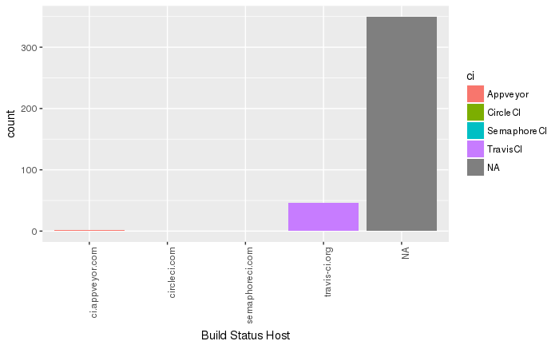

```r
repo_readme <- readRDS("repo_readme.rds")
# repos with a build status in the readme
ggplot(data = repo_readme,
       aes(x = build_status_host, fill=ci)) +
  geom_bar() +
  xlab("Build Status Host") +
  theme(axis.text.x = element_text(angle = 90, hjust = 1))
```

## In-repo Configuration Files

```r
# plot of repositories with .travis.yml in file contents
# yml_ci_sql <-
#   'select * from [bonnyci-github-archive:ci_plunder_travisci.yml_ci]'
#
# yml_ci <- query_exec(yml_ci_sql, project = project)
yml_ci <- yml_ci %>% mutate(
  ci=
    ifelse(name == ".travis.yml", "TravisCI",
                   ifelse(name == "appveyor.yml", "Appveyor",
                          ifelse(name =="circle.yml", "CircleCI", NA)
                   )
           )
)
saveRDS(yml_ci, "yml_ci.rds")
```

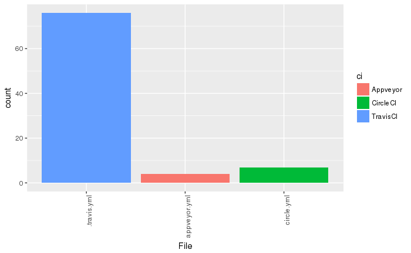

```r
yml_ci <- readRDS("yml_ci.rds")
ggplot(data = yml_ci,
       aes(x=name, fill=ci)) +
  geom_bar() +
  xlab("File") +
  theme(axis.text.x = element_text(angle = 90, hjust = 1))
```

## Statuses from Latest Pull Request

If a Github repository is integrated with an external service, that service will typically publish a status message when a new pull request is made. These statuses can be retrieved for public user-owned repositories and organization-owned repositories with relaxed pull access. For more information about Github statuses see https://developer.github.com/v3/repos/statuses/

Status messages will clearly indicate if a repository is configured to use an external CI pipeline because the host information is provided in the data fields. Similar to the build status tag approach, the hosts have been extracted from these fields.

```r
# statuses_sql <-
# 'select * from [bonnyci-github-archive:ci_plunder_travisci.pull_requests_statuses_hosts]'
#
# statuses <- query_exec(statuses_sql, project = project)
#
is.na(statuses$context) <- statuses$context == ""
statuses <- statuses %>% mutate(
  host=ifelse(!is.na(context_host), context_host,
              ifelse(!is.na(status_host), status_host, context))
)
saveRDS(statuses, "statuses.rds")
```

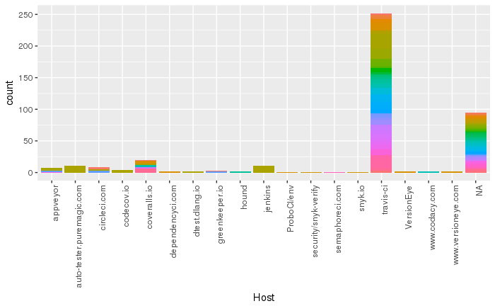

```r
# all hosts identified through statuses
statuses <- readRDS("statuses.rds")
# repos with a build status in the readme
ggplot(data = statuses,
       aes(x = host, fill=repo_slug)) +
  geom_bar() +
  xlab("Host") +
  theme(legend.position="none") +
  theme(axis.text.x = element_text(angle = 90, hjust = 1))
```

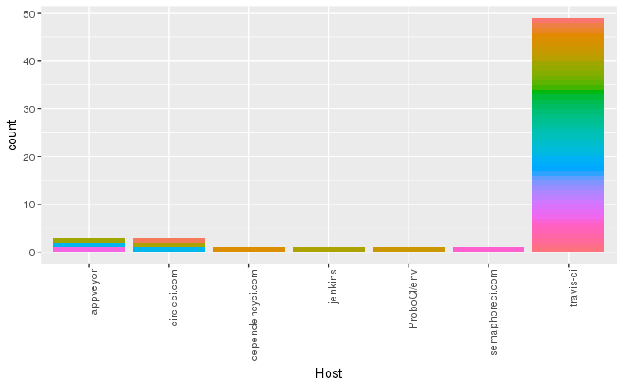

```r
statuses_context_ci <- statuses %>% mutate(
  context_ci = grepl("ci|continuous-integration", context, ignore.case = TRUE)
) %>%
  filter(context_ci == TRUE)
statuses_context_ci_by_repo <- statuses_context_ci %>%
  group_by(repo_slug, host) %>%
  summarise(num_ci_statuses=n())

ggplot(data = statuses_context_ci_by_repo,
       aes(x = host, fill=repo_slug)) +
  geom_bar() +
  xlab("Host") +
  theme(legend.position="none") +
  theme(axis.text.x = element_text(angle = 90, hjust = 1))
```

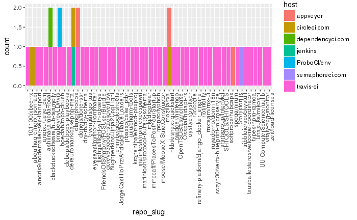

```r
ggplot(data = statuses_context_ci_by_repo,
       aes(x = repo_slug, fill=host)) +
  geom_bar() +
  theme(axis.text.x = element_text(angle = 90, hjust = 1))
```

```r
# TODO: i really need to learn how to write R, this is just awful
statuses_ci <- statuses_context_ci_by_repo %>%
  mutate(
    ci= ifelse(host=="travis-ci", "TravisCI",
                       ifelse(host=="appveyor", "Appveyor",
                              ifelse(host=="circleci.com", "CircleCI",
                                     ifelse(host=="jenkins", "Jenkins",
                                            ifelse(host=="ProboCI/env", "ProboCI",
                                                   ifelse(host=="semaphoreci.com", "SemaphoreCI",
                                                          ifelse(host=="dependencyci.com", "DependencyCI",
                                                                 NA)))))))
    )
```

A shortcoming of this method is that statuses cannot identify if a repository is using CI if the repository is not integrated with the external CI pipeline. This can happen if the repository isn’t actually hosted on Github and is just mirrored or if the project has a custom CI pipeline that is external to Github (again, if the repository is mirrored).

We will look at this in the next section to see how many repositories that failed to be identified through this method were identified through the other methods.

The other problem with status messages is that if an organization-owned repository is not configured to allow public read/pull access, then the only users who can get status information on pull requests have to have those permissions. This means organization-owned repositories may be misrepresented as not using CI through this method.

What proportion of the repositories in the sample are organization-owned?

Around 22% of the repositories were owned by organizations, just under 1/4 of the sample.

```r
# orgs_sql <-
# 'select * from [bonnyci-github-archive:ci_plunder_travisci.ghevents_repo_names_org]'
# orgs <- query_exec(orgs_sql, project = project)
orgs <- orgs %>% mutate(
  type = ifelse(is.na(org), "USER", "ORG")
)
saveRDS(orgs, "orgs.rds")
```

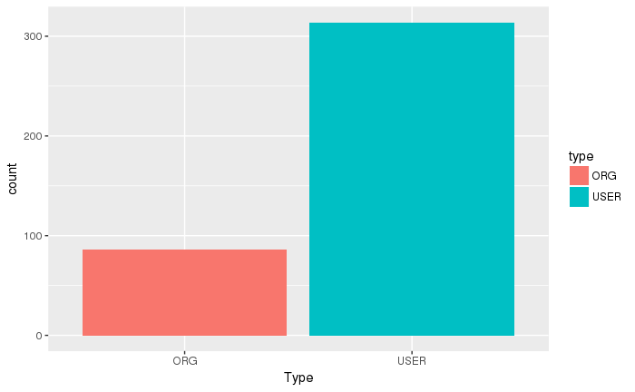

```r
orgs <- readRDS("orgs.rds")
ggplot(data = orgs,
       aes(x=type, fill=type)) +
  geom_bar() +
  xlab("Type")
```

Of the repositories that had pull requests, how many had statuses and were they user- or organization-owned?

```r
# pull_requests_statuses_vs_owner_type
status_vs_org_sql <-
  'select * from [bonnyci-github-archive:ci_plunder_travisci.pull_requests_statuses_vs_owner_type]'
status_vs_org <- query_exec(status_vs_org_sql, project = project)
```

```
Auto-refreshing stale OAuth token.
```

```r
saveRDS(status_vs_org, "status_vs_org.rds")
```

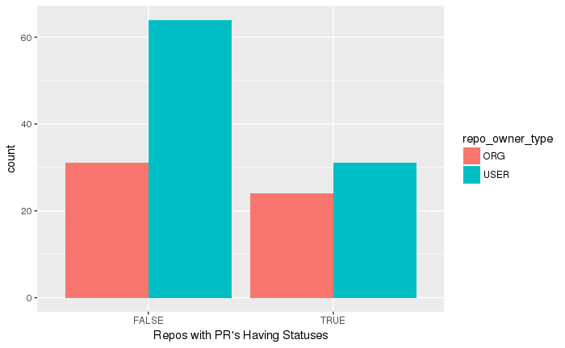

```r
status_vs_org <- readRDS("status_vs_org.rds")
ggplot(data = status_vs_org,
       aes(x=has_statuses, fill=repo_owner_type)) +
  geom_bar(position="dodge") +
  xlab("Repos with PR's Having Statuses")
```

## Text Search

Event text searches for “CI” didn’t produce any identifications that could be identified through other methods and the ones that were not identified by other methods did not use CI. Additionally, at this stage the context of the values searched had to be manually evaluated.

```r
# payload_sql <-
#   'select * from [bonnyci-github-archive:ci_plunder_travisci.payload_summary]'
#
# payload <- query_exec(payload_sql, project = project)
#
payload <- payload %>% mutate(
  ci = ifelse(payload == '[Tt]ravis', "TravisCI",
              ifelse(payload == '[Jj]enkins', "Jenkins",
                     "Unknown CI"))
)
saveRDS(payload, "payload.rds")
```

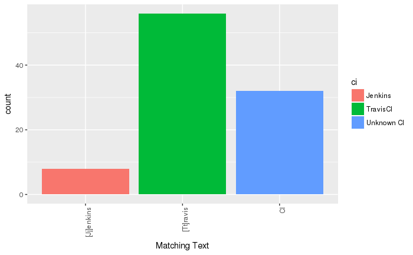

```r
payload <- readRDS("payload.rds")
ggplot(data = payload,
       aes(x=payload, fill=ci)) +
  geom_bar() +
  xlab("Matching Text") +
  theme(axis.text.x = element_text(angle = 90, hjust = 1))
```

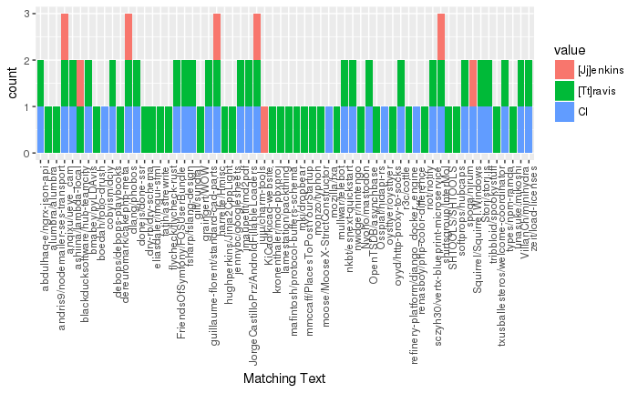

```r
payload_melt <- melt(payload %>% select(repo_slug, ci, payload), id=c("repo_slug", "ci"))
ggplot(data = payload_melt,
       aes(x=repo_slug, fill=value)) +
  geom_bar() +
  xlab("Matching Text") +
  theme(axis.text.x = element_text(angle = 90, hjust = 1))
```

## Comparison

How many repos overall did each method identify?

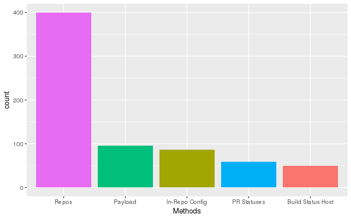

```r
statuses_count <-nrow(statuses_ci %>% filter(!is.na(ci)) %>% select(repo_slug))
yml_ci_count <- nrow(yml_ci %>% filter(!is.na(ci)) %>% select(repo_slug))
build_status_host_count <- nrow(repo_readme %>% filter(!is.na(ci)) %>% select(repo_slug))
payload_count <- nrow(payload %>% filter(!is.na(ci)) %>% select(repo_slug))
all_repos <- 400
ci_compare <- data.frame(count=c(build_status_host_count,
                                 yml_ci_count,
                                 statuses_count,
                                 payload_count,
                                 all_repos),
                           value=c("Build Status Host",
                                   "In-Repo Config",
                                   "PR Statuses",
                                   "Payload",
                                   "Repos"))
ggplot(data = ci_compare,
       aes(x=reorder(value, -count), y=count, fill=value)) +
  geom_bar(stat="identity") +
  xlab("Methods") +
  #theme(axis.text.x = element_text(angle = 90, hjust = 1)) +
  theme(legend.position="none")
ggsave("ci_identification_methods.png")
```

What was the overlap? Did some methods identify repos that the others missed?

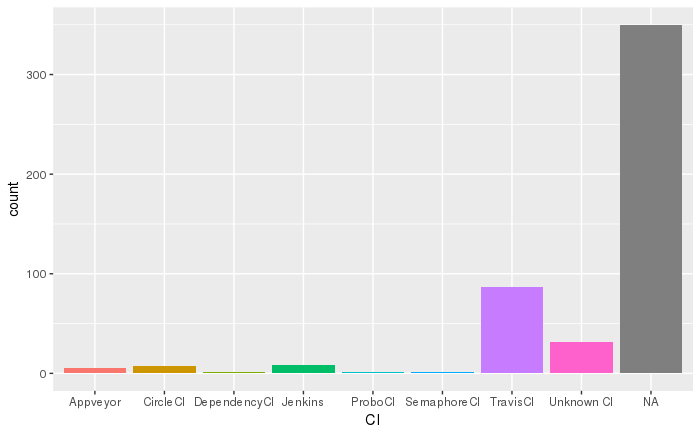

```r
overall_ci <- bind_rows(yml_ci %>% select(repo_slug, name, ci),
          repo_readme %>% select(repo_slug, build_status_host, ci),
          statuses_ci %>% select(repo_slug, host, ci),
          payload %>% select(repo_slug, payload, ci))
overall_ci_melt <- melt(overall_ci, id=c("repo_slug", "ci"))
overall_ci_melt_summary <- overall_ci_melt %>%
  group_by(ci, repo_slug) %>%
  summarise(freq=n())
ggplot(data = overall_ci_melt_summary,
       aes(x=ci, fill=ci)) +
  geom_bar() +
  theme(legend.position="none") +
  xlab("CI")
ggsave("ci_identification.png")
```

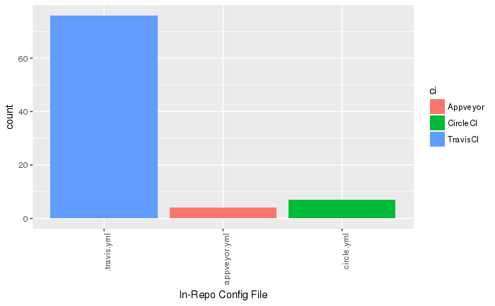

```r
overall_ci_melt <- overall_ci_melt %>% filter(!is.na(value))
ggplot(data = overall_ci_melt %>% filter(variable == "name"),
       aes(x=value, fill=ci)) +
  geom_bar() +
  xlab("In-Repo Config File") +
  theme(axis.text.x = element_text(angle = 90, hjust = 1))
```

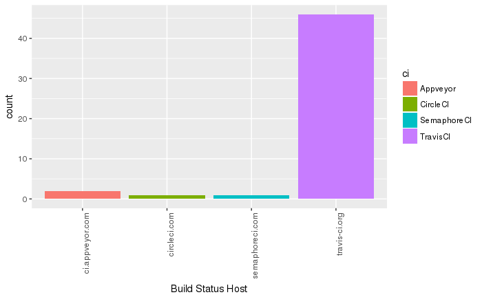

```r
ggplot(data = overall_ci_melt %>% filter(variable == "build_status_host"),
       aes(x=value, fill=ci)) +
  geom_bar() +
  xlab("Build Status Host") +
  theme(axis.text.x = element_text(angle = 90, hjust = 1))
```

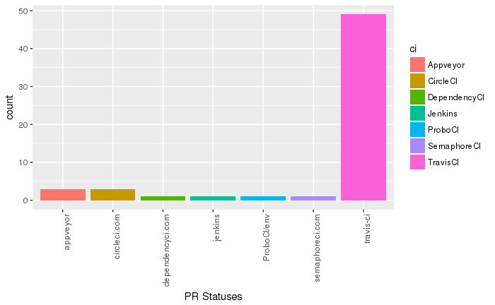

```r
ggplot(data = overall_ci_melt %>% filter(variable == "host"),
       aes(x=value, fill=ci)) +
  geom_bar() +
  xlab("PR Statuses") +
  theme(axis.text.x = element_text(angle = 90, hjust = 1))
```

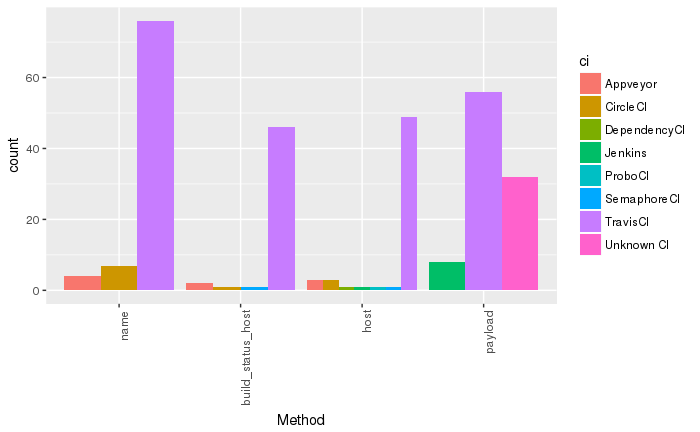

```r
ggplot(data = overall_ci_melt,
       aes(x=variable, fill=ci)) +
  geom_bar(position="dodge") +
  xlab("Method") +
  theme(axis.text.x = element_text(angle = 90, hjust = 1))
ggsave("ci_identification_methods_detail.png")
```

```r
ci_methods <- overall_ci %>%
  mutate(
    has_name = ifelse(is.na(name), 0, 1),
    has_build_status_host = ifelse(is.na(build_status_host), 0, 1),
    has_host =  ifelse(is.na(host), 0, 1),
    has_payload =  ifelse(is.na(payload), 0, 1),
    is_travis =  ifelse(ci == "TravisCI", 1, 0),
    is_jenkins =  ifelse(ci == "Jenkins", 1, 0),
    is_unknown =  ifelse(ci == "Unknown CI", 1, 0)
  )
# summarize by repo
ci_methods_by_repo <- ci_methods %>%
  group_by(repo_slug, ci) %>%
  summarise(
    name = sum(has_name),
    build_status_host = sum(has_build_status_host),
    host = sum(has_host),
    payload = sum(has_payload),
    TravisCI = sum(is_travis),
    Jenkins = sum(is_jenkins),
    Unknown = sum(is_unknown)
  )
```

Which methods successfully identified TravisCI?

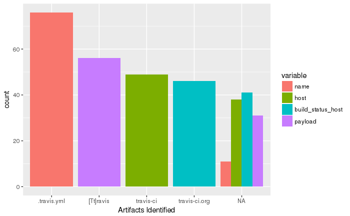

```r
overall_ci_travis <- overall_ci %>% filter(ci == "TravisCI") %>% select(repo_slug, name, host, build_status_host, payload)
overall_ci_travis_melt <- melt(overall_ci_travis, id="repo_slug")
overall_ci_travis_melt_summary <- overall_ci_travis_melt %>%
  arrange(repo_slug, variable, value) %>%
  group_by(repo_slug, variable) %>%
  summarise(
    value = first(value)
  )
ggplot(data = overall_ci_travis_melt_summary,
       aes(x=value, fill=variable)) +
  geom_bar(position="dodge") +
  xlab("Artifacts Identified")
ggsave("overall_travis.png")
```

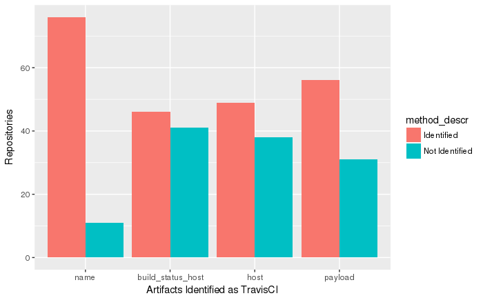

```r
ci_methods_travis <- ci_methods_by_repo %>% filter(ci == "TravisCI")
ci_methods_travis_melt <- melt(ci_methods_travis %>%
                                 select(repo_slug, name, build_status_host, host, payload),
                               id="repo_slug", value.name = "method_value")
ci_methods_travis_melt <- ci_methods_travis_melt %>%
  mutate(
    method=variable,
    method_descr=ifelse(method_value==0, "Not Identified", "Identified")
         ) %>%
  select(repo_slug, method, method_value, method_descr)
ci_methods_travis_melt_by_method <- ci_methods_travis_melt %>%
  group_by(method, method_descr) %>%
  summarise(
    num_repos = n()
  )
ggplot(data = ci_methods_travis_melt_by_method,
       aes(x=reorder(method, -num_repos), y=num_repos, fill=method_descr)) +
  geom_bar(stat="identity", position="dodge") +
  xlab("Artifacts Identified as TravisCI") +
  ylab("Repositories")
ggsave("overall_travis_by_method.png")
```

The advantage to the payload search is it can be done in Google BigQuery and isn’t capped by the Github API’s rate limiting. The disadvantage is that it’s not accurate and repositories will be missed if this method is used alone. Additional analysis is needed to determine what factors contributed to failed identification. For instance, is repo age a factor? Older repos might have less CI churn which would explain why a payload wouldn’t hit specifically for those terms.

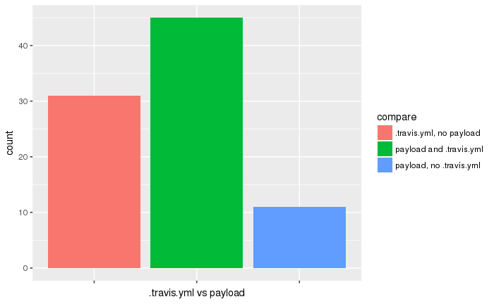

```r
ci_methods_travis_compare <- ci_methods_travis %>%
  mutate(
    compare = ifelse(
      name==1 & payload == 0, ".travis.yml, no payload", ifelse(
        name==0 & payload == 1, "payload, no .travis.yml", ifelse(
          name==1 & payload == 1, "payload and .travis.yml", ifelse(
            name==0 & payload==0, "no payload or .travis.yml", NA
          )
        )
      )
    )
  )
ggplot(data = ci_methods_travis_compare,
       aes(x=compare, fill=compare)) +
  geom_bar(position="dodge") +
  xlab(".travis.yml vs payload") +
  theme(axis.text.x = element_blank())
ggsave("travis_yml_vs_payload.png")
```

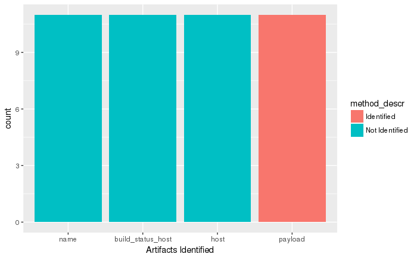

```r
travis_payload_only <- ci_methods_travis %>% filter(name==0 & payload == 1) %>% select(repo_slug)
travis_payload_only_melt <- merge(ci_methods_travis_melt, travis_payload_only, id="repo_slug")
ggplot(data = travis_payload_only_melt,
       aes(x=method, fill=method_descr)) +
  geom_bar(position="dodge") +
  xlab("Artifacts Identified")
```

```r
repos_travis_payload_only_sql <- paste(
  "SELECT * FROM [bonnyci-github-archive:ci_plunder_travisci.payload_travis] WHERE repo_slug IN('",
    paste(as.character(travis_payload_only$repo_slug), collapse="','"),
  "')",
  sep="")
repos_travis_payload_only <- query_exec(repos_travis_payload_only_sql, project = project)
```

```
Auto-refreshing stale OAuth token.
```

```r
saveRDS(repos_travis_payload_only, "repos_travis_payload_only.rds")
```

```r
repos_travis_payload_only <- readRDS("repos_travis_payload_only.rds")
repos_travis_payload_only_summary <- repos_travis_payload_only %>%
  group_by(event_type, repo_slug) %>% summarise(all_repos=n()) %>% group_by(event_type) %>% summarise(num_repos=n())
```

```r
repos_travis_payload_only_verification <- read.csv("repos_travis_payload_only_verification.csv")
repos_travis_payload_only_verification
```

| repo_slug | uses_travisci | payload_context |
| --- | --- | --- |
| abdulhaq-e/ngrx-json-api | No | Dependent Library |
| dlang/phobos | No | Request to Add |
| eliasdaler/imgui-sfml | No | Dependent Library |
| flycheck/flycheck-rust | No | Dependent Library |
| fsharp/fslang-design | No | Person's Name |
| gilt/sundial | No | Request to Add |
| harrelfe/Hmisc | No | Dependent Library |
| jmaupetit/md2pdf | No | Request to Add |
| lamestation/packthing | No | Request to Add |
| nkbt/esnext-quickstart | No | Dependent Library |

[output cut: 1 more lines]

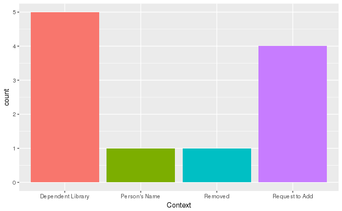

```r
ggplot(data = repos_travis_payload_only_verification,
       aes(x=payload_context, fill=payload_context)) +
  geom_bar(position="dodge") +
  xlab("Context") +
  theme(legend.position="none")
ggsave("travis_payload_context.png")
```

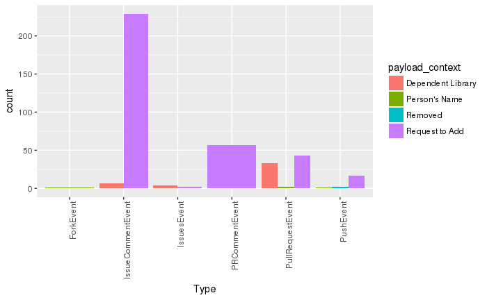

```r
repos_travis_payload_all <- merge(repos_travis_payload_only_verification, repos_travis_payload_only,
                                  by="repo_slug", all=TRUE)
repos_travis_payload_all <- repos_travis_payload_all %>% mutate(event_type=ifelse(event_type=="PullRequestReviewCommentEvent", "PRCommentEvent", event_type))
ggplot(data = repos_travis_payload_all,
       aes(x=event_type, fill=payload_context)) +
  geom_bar(position="dodge") +
  theme(axis.text.x = element_text(angle = 90, hjust = 1)) +
  xlab("Type")
```

```r
repos_travis_name_payload <- ci_methods_travis %>% filter(name==1 & payload == 1) %>% select(repo_slug)
travis_name_payload_sql <- paste(
  "SELECT * FROM [bonnyci-github-archive:ci_plunder_travisci.payload_travis] WHERE repo_slug IN('",
    paste(as.character(repos_travis_name_payload$repo_slug), collapse="','"),
  "')",
  sep="")
travis_name_payload <- query_exec(travis_name_payload_sql, project = project)
```

```
Auto-refreshing stale OAuth token.
```

```r
saveRDS(travis_name_payload, "travis_name_payload.rds")
```

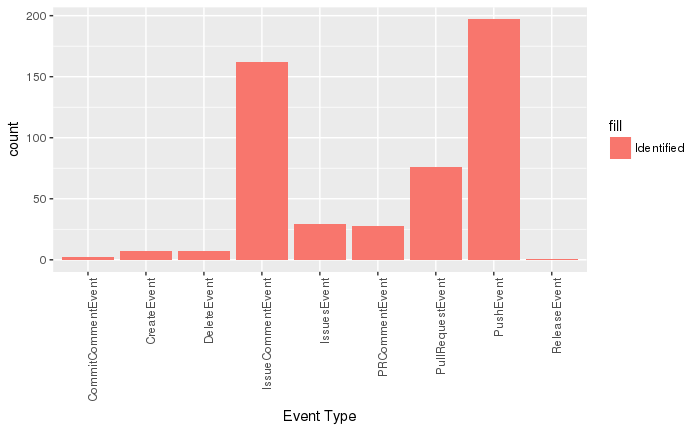

```r
travis_name_payload <- readRDS("travis_name_payload.rds")
travis_name_payload <- travis_name_payload %>%
  mutate(event_type=ifelse(event_type=="PullRequestReviewCommentEvent", "PRCommentEvent", event_type))
ggplot(data = travis_name_payload,
       aes(x=event_type, fill="Identified")) +
  geom_bar(position="dodge") +
  theme(axis.text.x = element_text(angle = 90, hjust = 1)) +
  xlab("Event Type")
```

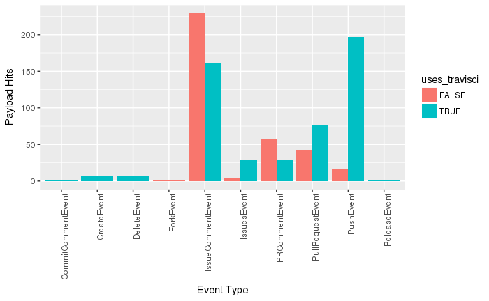

```r
travis_name_payload_summary <- travis_name_payload %>% mutate(payload_context="Uses TravisCI") %>%
  group_by(event_type, payload_context) %>% summarise(payload_hits = n(), uses_travisci=TRUE)
travis_payload_only_summary <- repos_travis_payload_all %>% group_by(event_type, payload_context) %>%
  summarise(payload_hits = n(), uses_travisci=FALSE)
travis_payload_event_types <- bind_rows(travis_name_payload_summary, travis_payload_only_summary)
ggplot(data = travis_payload_event_types,
       aes(x=event_type, y=payload_hits, fill=uses_travisci)) +
  geom_bar(position="dodge", stat="identity") +
  theme(axis.text.x = element_text(angle = 90, hjust = 1)) +
  xlab("Event Type") +
  ylab("Payload Hits")
```

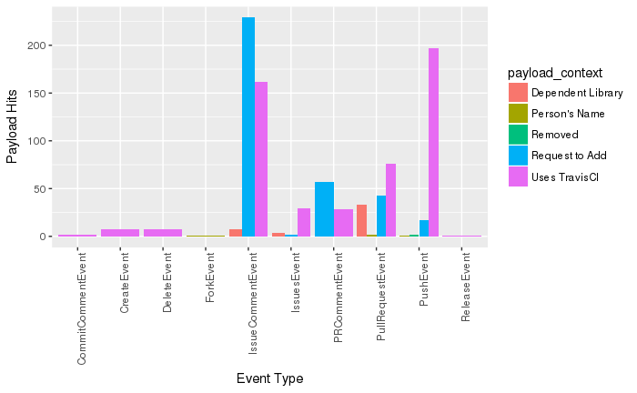

```r
ggplot(data = travis_payload_event_types,
       aes(x=event_type, y=payload_hits, fill=payload_context)) +
  geom_bar(position="dodge", stat="identity") +
  theme(axis.text.x = element_text(angle = 90, hjust = 1)) +
  xlab("Event Type") +
  ylab("Payload Hits")
ggsave("travis_payload_context_num_hits.png")
```

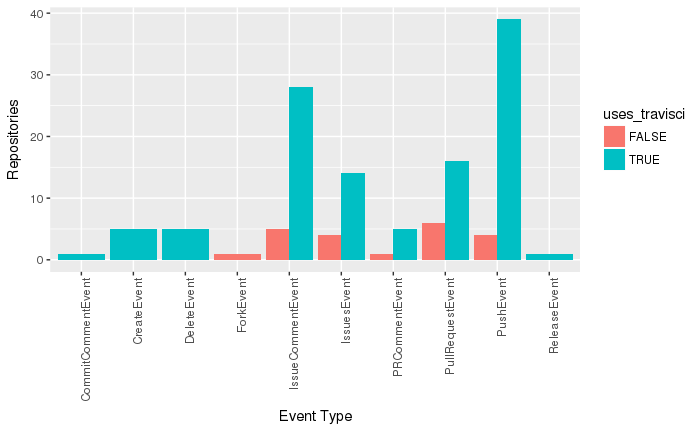

```r
travis_name_payload_summary_repo <- travis_name_payload %>% mutate(payload_context="Uses TravisCI") %>%
  group_by(event_type, payload_context, repo_slug) %>% summarise(payload_hits = n(), uses_travisci=TRUE)
travis_payload_only_summary_repo <- repos_travis_payload_all %>%
  group_by(event_type, payload_context, repo_slug) %>%
  summarise(payload_hits = n(), uses_travisci=FALSE)
travis_payload_event_types_repo <- bind_rows(travis_name_payload_summary_repo,
                                        travis_payload_only_summary_repo)
ggplot(data = travis_payload_event_types_repo,
       aes(x=event_type, fill=uses_travisci)) +
  geom_bar(position="dodge") +
  theme(axis.text.x = element_text(angle = 90, hjust = 1)) +
  xlab("Event Type") +
  ylab("Repositories")
```

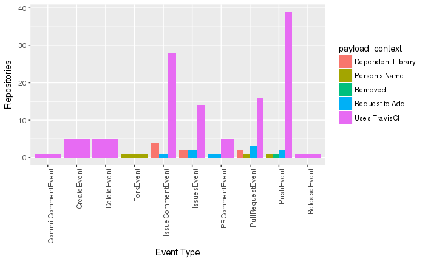

```r
ggplot(data = travis_payload_event_types_repo,
       aes(x=event_type, fill=payload_context)) +
  geom_bar(position="dodge") +
  theme(axis.text.x = element_text(angle = 90, hjust = 1)) +
  xlab("Event Type") +
  ylab("Repositories")
ggsave("travis_payload_context_num_repos.png")
```

```r
overall_ci_circle <- overall_ci %>% filter(ci == "CircleCI") %>% select(repo_slug, name, host, build_status_host)

overall_ci_circle_melt <- melt(overall_ci_circle, id="repo_slug")
overall_ci_circle_summary <- overall_ci_circle_melt %>%
  arrange(repo_slug, variable, value) %>%
  group_by(repo_slug, variable) %>%
  summarise(
    value = first(value)
  )


ggplot(data = overall_ci_circle_summary,
       aes(x=value, fill=variable)) +
  geom_bar(position="dodge") +
  xlab("Artifacts Identified")
```

[output not shown]

# Conclusions

For repos that use in-repo configuration, the best way to identify them is to use the Github api to look for those files in a sample. To identify what these CI might be, checking the hosts in the pull request statuses gleaned the best results. The overhead for this is comprable to the build status host in readme as both require a single API call and the use of text parsing to extract the host information.

Finally, payload text search is an option to consider for CI that do not use in-repo configuration, however the overhead is potentially very high as these need to be cross-checked against other identification methods and the accuracy is poor. Payload text search, however, has the potential to indicate past CI usage or a desire for future CI usuage. Additionally, there is an opportunity for applying Machine Learning or NLP techniques to discover patterns that could indicate whether a repo is likely to be using CI or not.